# Chapter 8: Introduction to linear regression

# Exercice 9

Based on the residuals vs. fitted plot, does the constant variability condition appear to be met? based on the residuals vs. fitted plot, there no pattern in the plot , which mean our assumption of constant variance (constant variability) condition appear to be met.

## More Practice

Choose another freedom variable and a variable you think would strongly correlate with it.. Produce a scatterplot of the two variables and fit a linear model. At a glance, does there seem to be a linear relationship? Display the relationship between the personal freedom rank, pf_rank, and pf_association as the predictor.

```r
view(hfi)
# Just replicate few lines from above, this time with new variable hf_score  pf_association, pf_rank
hfi4 <- select(hfi, pf_association, pf_rank )
#checking how many values are missing in hfi
sum(is.na(hfi4))
```

```
## [1] 409
```

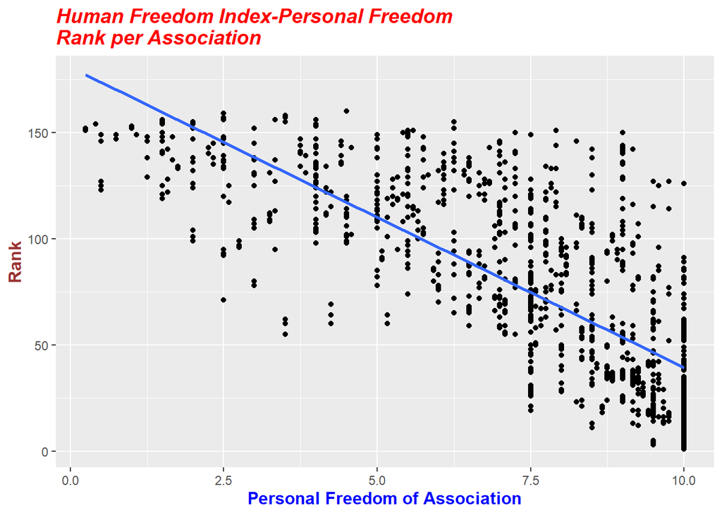

```r
hfi4 <- na.omit(hfi4)

#actually let's see a fit line
ggplot(hfi4, aes(x=pf_association, y=pf_rank)) + geom_point() +
  geom_smooth(method = "lm", se = FALSE) +
  ggtitle("Human Freedom Index-Personal Freedom \nRank per Association") +
  xlab("Personal Freedom of Association") + ylab("Rank") + theme
```

How does this relationship compare to the relationship between pf_expression_control and pf_score? Use the R2 values from the two model summaries to compare. Does your independent variable seem to predict your dependent one better? Why or why not? Answer: coefficient of determination/coefficient of multiple determination/R-squared is a statistical measure of how close the data are to the fitted regression line. if R-squared = 100%, then the model explain all the variability of the response data around its mean. In other word, there is no variance in the dependent variable that can be explained by the predictors

pf_expression_control and pf_score: multiple R-squared = 0.6342 ~ 63.4% pf_association and pf_rank: multiple R-Squared = 0.5804 ~58%

Based on the R-squared of the two relationships , there is about 5.4$ of a difference. The independent variable or predictor or explanatory (pf_association) does not seem to predict better the dependent variable or response variable or outcome variable. And that is the coefficient of correlation of the relationship between pf_association and pf_rank downhill(negative) -0.7618509 while the relationship between pf_expression_control and pf_score has a better coefficient of correlation uphill(positive) 0.7963894.

```r
m3 <- lm(pf_rank ~ pf_association, data = hfi4)
summary(m1)
```

```
##
## Call:
## lm(formula = pf_score ~ pf_expression_control, data = hfi2)
##
## Residuals:
##     Min      1Q  Median      3Q     Max
## -3.8467 -0.5704  0.1452  0.6066  3.2060
##
## Coefficients:
##                       Estimate Std. Error t value Pr(>|t|)
## (Intercept)            4.61707    0.05745   80.36   <2e-16 ***
## pf_expression_control  0.49143    0.01006   48.85   <2e-16 ***
## ---
## Signif. codes:  0 '***' 0.001 '**' 0.01 '*' 0.05 '.' 0.1 ' ' 1
##
## Residual standard error: 0.8318 on 1376 degrees of freedom
## Multiple R-squared:  0.6342, Adjusted R-squared:  0.634
## F-statistic:  2386 on 1 and 1376 DF,  p-value: < 2.2e-16
```

```r
summary(m3)
```

```
##
## Call:
## lm(formula = pf_rank ~ pf_association, data = hfi4)
##
## Residuals:
##     Min      1Q  Median      3Q     Max
## -76.308 -21.902  -6.476  20.781  96.455
##
## Coefficients:
##                Estimate Std. Error t value Pr(>|t|)
## (Intercept)    180.7927     2.8036   64.49   <2e-16 ***
## pf_association -14.1386     0.3581  -39.48   <2e-16 ***
## ---
## Signif. codes:  0 '***' 0.001 '**' 0.01 '*' 0.05 '.' 0.1 ' ' 1
##
## Residual standard error: 29.91 on 1127 degrees of freedom
## Multiple R-squared:  0.5804, Adjusted R-squared:   0.58
## F-statistic:  1559 on 1 and 1127 DF,  p-value: < 2.2e-16
```

```r
cor(hfi4$pf_association, hfi4$pf_rank)
```

```
## [1] -0.7618509
```

```r
cor(hfi2$pf_expression_control, hfi2$pf_score)
```

```
## [1] 0.7963894
```

What’s one freedom relationship you were most surprised about and why? Display the model diagnostics for the regression model analyzing this relationship. Answer: pf_expression_internet, pf_expression…considering the penetration of internet and human rights world wide , we expect this relationship to be close to best fit. Howerver , it is not the case

```r
hfi5 <- select(hfi, pf_expression_internet, pf_expression)
#checking how many values are missing in hfi
sum(is.na(hfi5))
```

```
## [1] 409
```

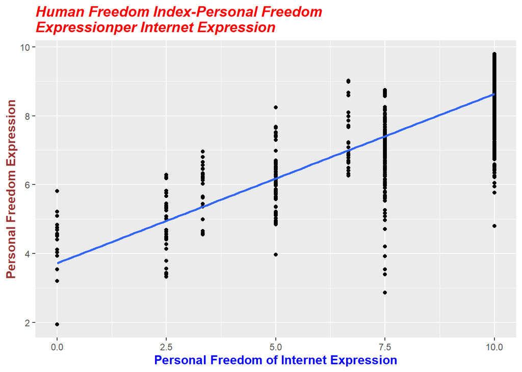

```r
hfi5 <- na.omit(hfi5)

ggplot(hfi5, aes(x=pf_expression_internet, y=pf_expression)) + geom_point() +
  geom_smooth(method = "lm", se = FALSE) +
  ggtitle("Human Freedom Index-Personal Freedom \nExpressionper Internet Expression ") +
  xlab("Personal Freedom of Internet Expression") + ylab("Personal Freedom Expression") + theme
```

```r
m5 <- lm(pf_expression ~ pf_expression_internet, data = hfi5)

summary(m5)
```

```
##
## Call:
## lm(formula = pf_expression ~ pf_expression_internet, data = hfi5)
##
## Residuals:
##     Min      1Q  Median      3Q     Max
## -4.5446 -0.5575  0.0862  0.7155  2.0895
##
## Coefficients:
##                        Estimate Std. Error t value Pr(>|t|)
## (Intercept)             3.72006    0.10012   37.15   <2e-16 ***
## pf_expression_internet  0.49170    0.01128   43.59   <2e-16 ***
## ---
## Signif. codes:  0 '***' 0.001 '**' 0.01 '*' 0.05 '.' 0.1 ' ' 1
##
## Residual standard error: 0.8949 on 1127 degrees of freedom
## Multiple R-squared:  0.6277, Adjusted R-squared:  0.6274
## F-statistic:  1900 on 1 and 1127 DF,  p-value: < 2.2e-16
```

```r
cor(hfi5$pf_expression_internet, hfi5$pf_expression)
```

```
## [1] 0.7922678
```

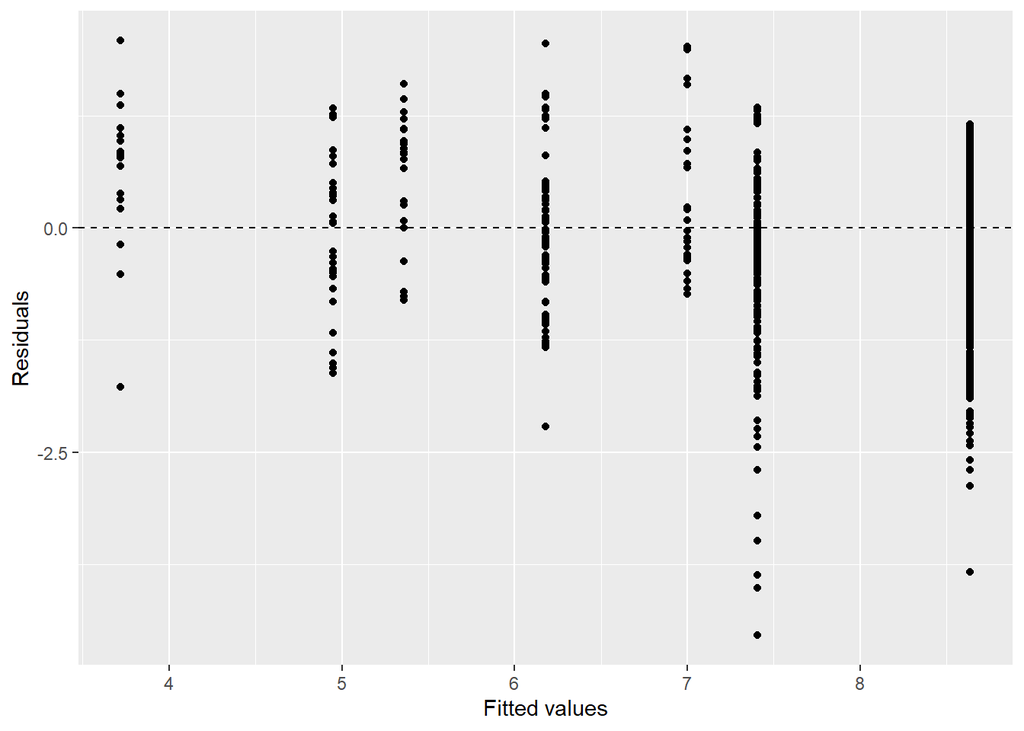

```r
ggplot(data = m5, aes(x = .fitted, y = .resid)) +
  geom_point() +
  geom_hline(yintercept = 0, linetype = "dashed") +
  xlab("Fitted values") +
  ylab("Residuals")
```

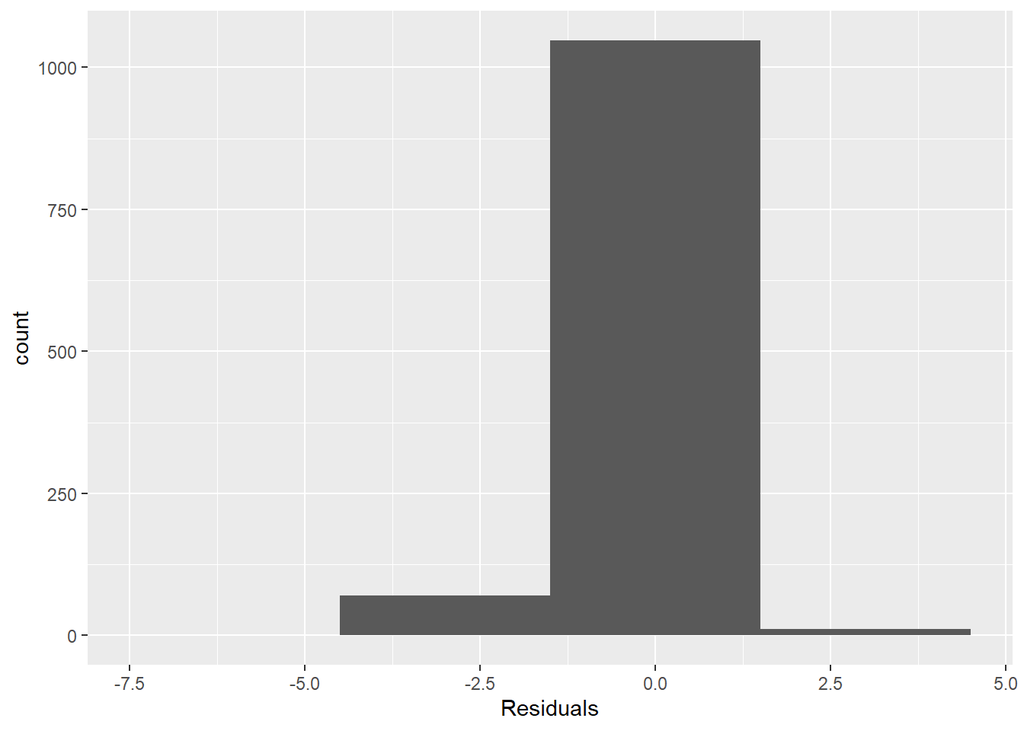

```r
ggplot(data = m5, aes(x = .resid)) +
  geom_histogram(binwidth = 3) +
  xlab("Residuals")
```

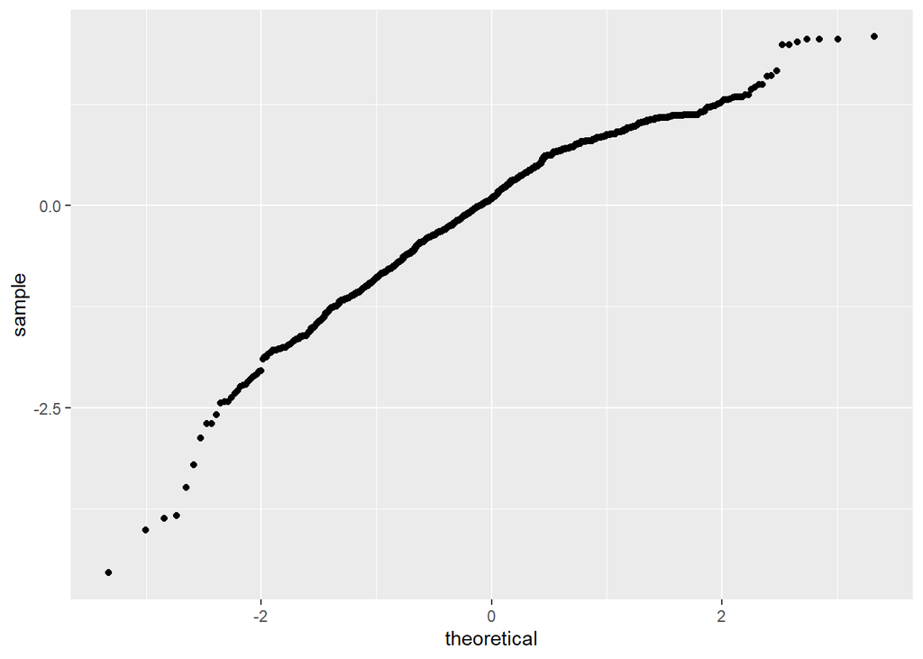

```r
ggplot(data = m5, aes(sample = .resid)) +
  stat_qq()
```